# STA141B SQL and Relational Databases

Bohan Chen

2025-05-17

## 1. How many teams are there in the database? how many teams are there in 2022? List the names of the teams for 2022,including the league and division they are in and how many games they won and lost in that year. Group the results by league, division and then by games won.

```r
library(DBI)
library(RSQLite)

con <- dbConnect(RSQLite::SQLite(), "/Users/chenbohan/Desktop/lahman_1871-2022.sqlite")
dbListTables(con)
```

```
##  [1] "AllstarFull"         "Appearances"         "AwardsManagers"
##  [4] "AwardsPlayers"       "AwardsShareManagers" "AwardsSharePlayers"
##  [7] "Batting"             "BattingPost"         "CollegePlaying"
## [10] "Fielding"            "FieldingOF"          "FieldingOFsplit"
## [13] "FieldingPost"        "HallOfFame"          "HomeGames"
## [16] "Managers"            "ManagersHalf"        "Parks"
## [19] "People"              "Pitching"            "PitchingPost"
## [22] "Salaries"            "Schools"             "SeriesPost"
## [25] "Teams"               "TeamsFranchises"     "TeamsHalf"
```

```r
# 1. Total number of distinct teams in the full database
dbGetQuery(con, "
  SELECT COUNT(DISTINCT teamID) AS total_teams
  FROM Teams
")
```

```
##   total_teams
## 1         149
```

```r
# 2. Number of teams that played in 2022
dbGetQuery(con, "
  SELECT COUNT(*) AS teams_in_2022
  FROM Teams
  WHERE yearID = 2022
")
```

```
##   teams_in_2022
## 1            30
```

```r
# 3. List of team names and stats for 2022, grouped by league/division and sorted by wins
teams_2022 <- dbGetQuery(con, "
  SELECT name, lgID AS league, divID AS division, W AS wins, L AS losses
  FROM Teams
  WHERE yearID = 2022
  ORDER BY league, division, wins DESC
")
print(teams_2022)
```

```
##                             name league division wins losses
## 1            Cleveland Guardians     AL        C   92     70
## 2              Chicago White Sox     AL        C   81     81
## 3                Minnesota Twins     AL        C   78     84
## 4                 Detroit Tigers     AL        C   66     96
## 5             Kansas City Royals     AL        C   65     97
## 6               New York Yankees     AL        E   99     63
## 7              Toronto Blue Jays     AL        E   92     70
## 8                 Tampa Bay Rays     AL        E   86     76
## 9              Baltimore Orioles     AL        E   83     79
## 10                Boston Red Sox     AL        E   78     84
## 11                Houston Astros     AL        W  106     56
## 12              Seattle Mariners     AL        W   90     72
## 13 Los Angeles Angels of Anaheim     AL        W   73     89
## 14                 Texas Rangers     AL        W   68     94
```

[output cut: 16 more lines]

Interpretation: There have been 149 different team IDs in the MLB database historically, and 30 teams were in the 2022 season.

Explanation: I used three queries to: Count the number of distinct teamID values to capture historical team variety. Count rows where yearID = 2022 to get current teams. Select team names and win/loss records for 2022 and sort them by league, division, and number of wins to group the output meaningfully.

Figure Out: The teamID is used to track franchises across years, even if names or cities change. The lgID and divID fields in the Teams table help group results by league and division.

## 2. What are the 10 teams that had the highest average attendance since 2015? Give the name and the average and total attendance for this period for each time.

```r
top_attendance <- dbGetQuery(con, "
  SELECT
    name,
    teamID,
    SUM(attendance) AS total_attendance,
    COUNT(attendance) AS seasons_played,
    ROUND(1.0 * SUM(attendance) / COUNT(attendance)) AS avg_attendance
  FROM Teams
  WHERE yearID >= 2015 AND attendance IS NOT NULL
  GROUP BY teamID, name
  ORDER BY avg_attendance DESC
  LIMIT 10
")
print(top_attendance)
```

```
##                             name teamID total_attendance seasons_played
## 1            Los Angeles Dodgers    LAN         25731893              8
## 2            St. Louis Cardinals    SLN         22720377              8
## 3               New York Yankees    NYA         21287486              8
## 4                   Chicago Cubs    CHN         20222772              8
## 5           San Francisco Giants    SFN         20070905              8
## 6  Los Angeles Angels of Anaheim    LAA         19060870              8
## 7                 Boston Red Sox    BOS         18924420              8
## 8               Colorado Rockies    COL         18608160              8
## 9              Milwaukee Brewers    MIL         17505787              8
## 10                Houston Astros    HOU         17459302              8
##    avg_attendance
## 1         3216487
## 2         2840047
## 3         2660936
## 4         2527847
## 5         2508863
## 6         2382609
## 7         2365553
## 8         2326020
## 9         2188223
## 10        2182413
```

Explanation: I filtered the Teams table for rows where yearID >= 2015 and attendance IS NOT NULL. I grouped by both teamID and name to ensure uniqueness. I used SUM(attendance) for total attendance and divided by the count of non-null attendance records to compute the average. ORDER BY avg_attendance DESC ranks the teams by their average attendance over the years. LIMIT 10 shows the top 10.

Figure Out:Grouping by both teamID and name helps ensure correct aggregation for teams with consistent branding.

## 3. Who are the 10 people that had the “longest” career, i.e., spans the largest number of years? Who are the 10 people that played the most number of games

```r
# Part (a): 10 players with the longest career span in years
longest_careers <- dbGetQuery(con, "
  SELECT
    p.nameFirst || ' ' || p.nameLast AS name,
    MIN(b.yearID) AS first_year,
    MAX(b.yearID) AS last_year,
    MAX(b.yearID) - MIN(b.yearID) + 1 AS career_span
  FROM Batting b
  JOIN People p ON b.playerID = p.playerID
  GROUP BY b.playerID
  ORDER BY career_span DESC
  LIMIT 10
")

# Part (b): 10 players who played the most total games
most_games <- dbGetQuery(con, "
  SELECT
    p.nameFirst || ' ' || p.nameLast AS name,
    SUM(b.G) AS total_games
  FROM Batting b
  JOIN People p ON b.playerID = p.playerID
  GROUP BY b.playerID
  ORDER BY total_games DESC
  LIMIT 10
")

print(longest_careers)
```

```
##               name first_year last_year career_span
## 1     Nick Altrock       1898      1933          36
## 2     Jim O'Rourke       1872      1904          33
## 3    Minnie Minoso       1949      1980          32
## 4  Charley O'Leary       1904      1934          31
## 5     Arlie Latham       1880      1909          30
## 6   Deacon McGuire       1884      1912          29
## 7     Johnny Evers       1902      1929          28
## 8  Hughie Jennings       1891      1918          28
## 9       Nolan Ryan       1966      1993          28
## 10    Gabby Street       1904      1931          28
```

```r
print(most_games)
```

```
##                name total_games
## 1         Pete Rose        3562
## 2  Carl Yastrzemski        3308
## 3        Hank Aaron        3298
## 4  Rickey Henderson        3081
## 5     Albert Pujols        3080
## 6           Ty Cobb        3035
## 7      Eddie Murray        3026
## 8       Stan Musial        3026
## 9        Cal Ripken        3001
## 10      Willie Mays        2992
```

Interpretation: Nick Altrock had the longest official career span 36 years,Pete Rose played the most games in MLB history 3562.

Explanation: Part (a) finds the longest time between first and last year played, using MIN() and MAX() on yearID from the Batting table. I added +1 to ensure inclusive counting (e.g., 2000–2001 = 2 years). Part (b) sums all games played (G) per player and ranks them.

## 4. Compute which team won the world series in 2022? Include the team name, league, division, number of games won and lost during the season, and the total number of games in the world series

```r
ws_2022 <- dbGetQuery(con, "
  SELECT
    t.name AS team_name,
    t.lgID AS league,
    t.divID AS division,
    t.W AS regular_season_wins,
    t.L AS regular_season_losses,
    s.wins + s.losses AS world_series_total_games
  FROM SeriesPost s
  JOIN Teams t
    ON s.teamIDwinner = t.teamID AND s.yearID = t.yearID
  WHERE s.yearID = 2022 AND s.round = 'WS'
")

print(ws_2022)
```

```
##        team_name league division regular_season_wins regular_season_losses
## 1 Houston Astros     AL        W                 106                    56
##   world_series_total_games
## 1                        6
```

Interpretation: The Houston Astros won the 2022 World Series. They are a member of the American League (AL) and play in the Western Division (W). During the regular season, they recorded 106 wins and 56 losses. The World Series lasted 6 games, indicating a 4–2 series result.

Explanation: The winner is identified from SeriesPost where round = ‘WS’ and yearID = 2022. The teamIDwinner in SeriesPost is joined with the Teams table to get full team information. The number of games played in the World Series was calculated as wins + losses from the SeriesPost table.

Figure Out: I had to join SeriesPost with Teams using both teamID and yearID to get team name, league, and division. s.wins + s.losses provided the total number of games played in the series, since no direct “total games” field exists.

## 5. Compute the winner and the loser of the world series for all years. Include the team name, league, division, number of games won and lost during the season for both the winning and the losing team

```r
ws_all_years <- dbGetQuery(con, "
  SELECT
    s.yearID,

    -- Winning team info
    t_win.name AS winner_name,
    t_win.lgID AS winner_league,
    t_win.divID AS winner_division,
    t_win.W AS winner_wins,
    t_win.L AS winner_losses,

    -- Losing team info
    t_lose.name AS loser_name,
    t_lose.lgID AS loser_league,
    t_lose.divID AS loser_division,
    t_lose.W AS loser_wins,
    t_lose.L AS loser_losses

  FROM SeriesPost s
  JOIN Teams t_win
    ON s.teamIDwinner = t_win.teamID AND s.yearID = t_win.yearID
  JOIN Teams t_lose
    ON s.teamIDloser = t_lose.teamID AND s.yearID = t_lose.yearID
  WHERE s.round = 'WS'
  ORDER BY s.yearID DESC
")

print(ws_all_years)
```

```
##     yearID             winner_name winner_league winner_division winner_wins
## 1     2022          Houston Astros            AL               W         106
## 2     2021          Atlanta Braves            NL               E          88
## 3     2020     Los Angeles Dodgers            NL               W          43
## 4     2019    Washington Nationals            NL               E          93
## 5     2018          Boston Red Sox            AL               E         108
## 6     2017          Houston Astros            AL               W         101
## 7     2016            Chicago Cubs            NL               C         103
## 8     2015      Kansas City Royals            AL               C          95
## 9     2014    San Francisco Giants            NL               W          88
## 10    2013          Boston Red Sox            AL               E          97
## 11    2012    San Francisco Giants            NL               W          94
## 12    2011     St. Louis Cardinals            NL               C          90
## 13    2010    San Francisco Giants            NL               W          92
## 14    2009        New York Yankees            AL               E         103
```

[output cut: 363 more lines]

Explanation: I used the SeriesPost table to get the World Series (round = ‘WS’) for each year. I joined the Teams table twice: once to get info for the winning team, and once for the losing team, using both teamID and yearID.

Explanation: I used the SeriesPost table to get the World Series (round = ‘WS’) for each year. I joined the Teams table twice: once to get info for the winning team, and once for the losing team, using both teamID and yearID.

## 6. Compute the total payroll for each team for each year. Plot these. Bonus: In the SQL query, also compute whether the team won or lost the world series for that year and add that to the plot

```r
payroll_ws <- dbGetQuery(con, "
  SELECT
    s.yearID,
    s.teamID,
    t.name AS team_name,
    SUM(s.salary) AS total_payroll,

    CASE
      WHEN s.teamID = sp.teamIDwinner THEN 'Winner'
      WHEN s.teamID = sp.teamIDloser THEN 'Loser'
      ELSE 'No'
    END AS world_series_result

  FROM Salaries s
  LEFT JOIN Teams t
    ON s.teamID = t.teamID AND s.yearID = t.yearID
  LEFT JOIN SeriesPost sp
    ON s.yearID = sp.yearID AND sp.round = 'WS'

  GROUP BY s.yearID, s.teamID
  ORDER BY s.yearID, total_payroll DESC
")
print(payroll_ws)
```

```
##     yearID teamID                     team_name total_payroll
## 1     1985    ATL                Atlanta Braves      14807000
## 2     1985    CAL             California Angels      14427894
## 3     1985    NYA              New York Yankees      14238204
## 4     1985    CHN                  Chicago Cubs      12702917
## 5     1985    SLN           St. Louis Cardinals      11817083
## 6     1985    BAL             Baltimore Orioles      11560712
## 7     1985    ML4             Milwaukee Brewers      11284107
## 8     1985    SDN              San Diego Padres      11036583
## 9     1985    LAN           Los Angeles Dodgers      10967917
## 10    1985    BOS                Boston Red Sox      10897560
## 11    1985    NYN                 New York Mets      10834762
## 12    1985    DET                Detroit Tigers      10348143
## 13    1985    PHI         Philadelphia Phillies      10124966
## 14    1985    HOU                Houston Astros       9993051
```

[output cut: 1823 more lines]

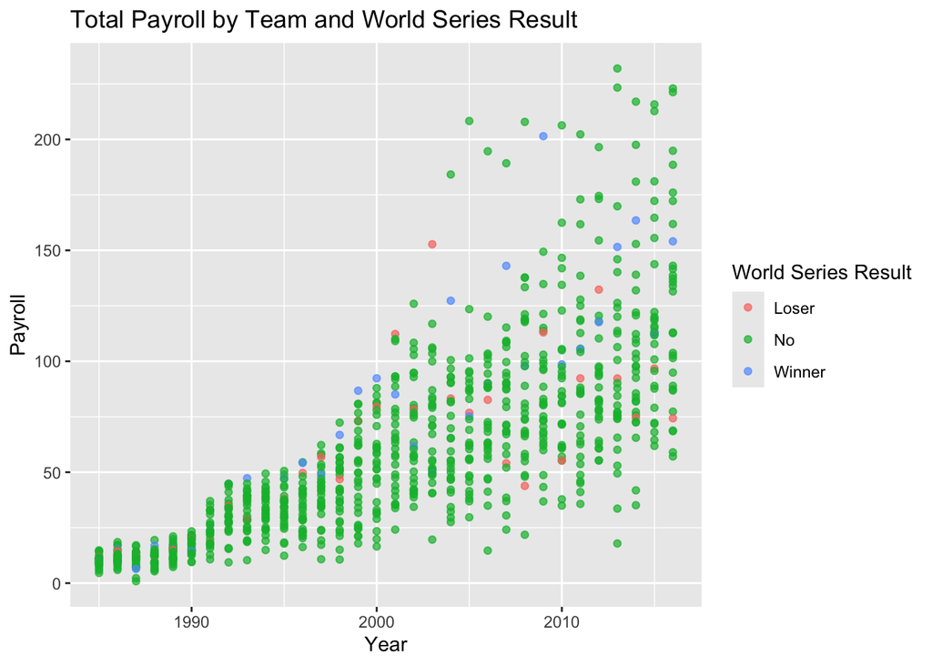

```r
library(ggplot2)
ggplot(payroll_ws, aes(x = yearID, y = total_payroll / 1e6, color = world_series_result)) +
  geom_point(alpha = 0.7) +
  labs(title = "Total Payroll by Team and World Series Result",
       x = "Year",
       y = "Payroll",
       color = "World Series Result")
```

Interpretation: Winning the World Series sometimes happens with mid-range payrolls, showing that success depends on more than just money. Payroll inflation is visible, with 1980s teams mostly below $30 million and post-2010 teams often exceeding $50 million.

Explanation: I joined Salaries with Teams to get names and divisions, and with SeriesPost to identify winners and losers. A CASE block determined whether each team was a World Series Winner, Loser, or Not in the WS. Payroll was aggregated per team per year using SUM(s.salary). The plot was created using ggplot2 and colored by WS result.

Figure Out:Data ends at 2016 for payroll (Salaries table) — that’s the latest year visible in the plot.

## 7. What are the 10 colleges/universities that have produced the most players in MLB since 2000? Give the college name, city and state and the number of players they have produced in this time period.

```r
top_colleges <- dbGetQuery(con, "
  SELECT
    sc.name_full AS college_name,
    sc.city,
    sc.state,
    COUNT(DISTINCT cp.playerID) AS num_players
  FROM CollegePlaying cp
  JOIN People p ON cp.playerID = p.playerID
  JOIN Schools sc ON cp.schoolID = sc.schoolID
  WHERE p.debut >= '2000-01-01'
  GROUP BY cp.schoolID
  ORDER BY num_players DESC
  LIMIT 10
")

print(top_colleges)
```

```
##                              college_name         city state num_players
## 1  California State University Long Beach   Long Beach    CA          29
## 2                     Stanford University    Palo Alto    CA          29
## 3                Arizona State University        Tempe    AZ          25
## 4   California State University Fullerton    Fullerton    CA          25
## 5       University of Southern California  Los Angeles    CA          25
## 6              Louisiana State University  Baton Rouge    LA          24
## 7                     University of Miami Coral Gables    FL          23
## 8           University of Texas at Austin       Austin    TX          22
## 9            University of South Carolina     Columbia    SC          21
## 10              Oklahoma State University   Stillwater    OK          20
```

Interpretation: California dominates the list, with 4 of the top 10 colleges coming from the state. Stanford University and Cal State Long Beach tie for the most MLB players 29 each.

Explanation: I joined CollegePlaying, People, and Schools to link player IDs to schools, filter by debut year, and retrieve location info. The debut field is stored in text, so filtering by ‘2000-01-01’ works correctly in SQLite. I used COUNT(DISTINCT cp.playerID) to avoid counting the same player more than once if they appeared in multiple college seasons. Sorting by number of players and using LIMIT 10 returned the top-producing programs.

Figure Out:University naming varies in the database, so I used schoolID not just name to ensure correct grouping.

## 8. How many all-star games are there each year? How many players are there in each all-star game(s) each year?

```r
# How many All-Star games per year
allstar_game_counts <- dbGetQuery(con, "
  SELECT
    yearID,
    COUNT(DISTINCT gameNum) AS num_allstar_games
  FROM AllstarFull
  GROUP BY yearID
  ORDER BY yearID
")

print(allstar_game_counts)
```

```
##    yearID num_allstar_games
## 1    1933                 1
## 2    1934                 1
## 3    1935                 1
## 4    1936                 1
## 5    1937                 1
## 6    1938                 1
## 7    1939                 1
## 8    1940                 1
## 9    1941                 1
## 10   1942                 1
## 11   1943                 1
## 12   1944                 1
## 13   1945                 1
## 14   1946                 1
```

[output cut: 75 more lines]

```r
# Number of players in each All-Star game
allstar_players_per_game <- dbGetQuery(con, "
  SELECT
    yearID,
    gameNum,
    COUNT(DISTINCT playerID) AS num_players
  FROM AllstarFull
  GROUP BY yearID, gameNum
  ORDER BY yearID, gameNum
")

print(allstar_players_per_game)
```

```
##    yearID gameNum num_players
## 1    1933       0          36
## 2    1934       0          41
## 3    1935       0          42
## 4    1936       0          43
## 5    1937       0          48
## 6    1938       0          48
## 7    1939       0          52
## 8    1940       0          53
## 9    1941       0          52
## 10   1942       0          53
## 11   1943       0          53
## 12   1944       0          54
## 13   1945       0          49
## 14   1946       0          52
```

[output cut: 78 more lines]

Explanation: The AllstarFull table lists individual player appearances in All-Star Games. I used COUNT(DISTINCT gameNum) to find how many games were played each year. I used COUNT(DISTINCT playerID) to find how many unique players appeared per game. The value of gameNum = 0 indicates the only game for each of these years.

## 9. Consider players who have appeared in at least 15 all-star games. How many all-star games have they played in? Give the players’ names, teams and years for each year, in which they were in the all-star games, and the first and last year they were in an all-star game.

```r
allstar_15plus <- dbGetQuery(con, "
  SELECT
    p.playerID,
    p.nameFirst || ' ' || p.nameLast AS name,
    COUNT(*) AS num_allstar_games,
    MIN(a.yearID) AS first_year,
    MAX(a.yearID) AS last_year
  FROM AllstarFull a
  JOIN People p ON a.playerID = p.playerID
  GROUP BY a.playerID
  HAVING COUNT(*) >= 15
  ORDER BY num_allstar_games DESC
")

print(allstar_15plus)
```

```
##     playerID             name num_allstar_games first_year last_year
## 1   mayswi01      Willie Mays                26       1954      1973
## 2  aaronha01       Hank Aaron                24       1955      1975
## 3  musiast01      Stan Musial                24       1943      1963
## 4  mantlmi01    Mickey Mantle                19       1952      1968
## 5  ripkeca01       Cal Ripken                19       1983      2001
## 6  willite01     Ted Williams                19       1940      1960
## 7  berrayo01       Yogi Berra                18       1948      1962
## 8  carewro01        Rod Carew                18       1967      1984
## 9  kalinal01        Al Kaline                18       1955      1974
## 10 robinbr01  Brooks Robinson                18       1960      1974
## 11 yastrca01 Carl Yastrzemski                18       1963      1983
## 12 clemero01 Roberto Clemente                17       1960      1972
## 13  rosepe01        Pete Rose                17       1965      1985
## 14 spahnwa01     Warren Spahn                16       1947      1963
## 15 aparilu01    Luis Aparicio                15       1958      1972
## 16   foxne01       Nellie Fox                15       1951      1963
## 17 gwynnto01       Tony Gwynn                15       1984      1999
## 18 smithoz01      Ozzie Smith                15       1981      1996
```

```r
allstar_details <- dbGetQuery(con, "
  SELECT
    p.nameFirst || ' ' || p.nameLast AS name,
    a.yearID,
    a.teamID
  FROM AllstarFull a
  JOIN People p ON a.playerID = p.playerID
  WHERE a.playerID IN (
    SELECT playerID
    FROM AllstarFull
    GROUP BY playerID
    HAVING COUNT(*) >= 15
  )
  ORDER BY name, yearID
")

print(allstar_details)
```

```
##                 name yearID teamID
## 1          Al Kaline   1955    DET
## 2          Al Kaline   1956    DET
## 3          Al Kaline   1957    DET
## 4          Al Kaline   1958    DET
## 5          Al Kaline   1959    DET
## 6          Al Kaline   1959    DET
## 7          Al Kaline   1960    DET
## 8          Al Kaline   1960    DET
## 9          Al Kaline   1961    DET
## 10         Al Kaline   1961    DET
## 11         Al Kaline   1962    DET
## 12         Al Kaline   1963    DET
## 13         Al Kaline   1964    DET
## 14         Al Kaline   1965    DET
```

[output cut: 317 more lines]

Interpretation: Willie Mays appeared in the most All-Star Games 26, followed closely by Hank Aaron and Stan Musial.

Interpretation: Willie Mays appeared in the most All-Star Games (26), followed closely by Hank Aaron and Stan Musial.

## 10. Find the 10 players who have appeared in the most number of years in the playoffs. This is the number of years, not the total number of playoff games they were in. Return the table with the person’s name, number of years they have been in the playoffs, the first and last year they appeared in the playoffs, and the number of different teams they appeared for in the playoffs. Bonus: Include the average salary (over all the years they played) for each of the individual

```r
playoff_years <- dbGetQuery(con, "
  SELECT
    p.nameFirst || ' ' || p.nameLast AS name,
    bp.playerID,
    COUNT(DISTINCT bp.yearID) AS num_playoff_years,
    MIN(bp.yearID) AS first_playoff_year,
    MAX(bp.yearID) AS last_playoff_year,
    COUNT(DISTINCT bp.teamID) AS num_playoff_teams
  FROM BattingPost bp
  JOIN People p ON bp.playerID = p.playerID
  GROUP BY bp.playerID
  ORDER BY num_playoff_years DESC
  LIMIT 10
")

print(playoff_years)
```

```
##              name  playerID num_playoff_years first_playoff_year
## 1     Derek Jeter jeterde01                16               1996
## 2  Mariano Rivera riverma01                16               1995
## 3    Jorge Posada posadjo01                15               1995
## 4      Yogi Berra berrayo01                14               1947
## 5   Andy Pettitte pettian01                14               1995
## 6     John Smoltz smoltjo01                14               1991
## 7     Greg Maddux maddugr01                13               1989
## 8   Yadier Molina molinya01                13               2004
## 9   Roger Clemens clemero02                12               1986
## 10    Tom Glavine glavito02                12               1991
##    last_playoff_year num_playoff_teams
## 1               2012                 1
## 2               2011                 1
## 3               2011                 1
## 4               1963                 1
## 5               2012                 2
## 6               2009                 2
## 7               2008                 3
## 8               2022                 1
## 9               2007                 3
## 10              2006                 2
```

```r
playoff_years_salary <- dbGetQuery(con, "
  SELECT
    p.nameFirst || ' ' || p.nameLast AS name,
    bp.playerID,
    COUNT(DISTINCT bp.yearID) AS num_playoff_years,
    MIN(bp.yearID) AS first_playoff_year,
    MAX(bp.yearID) AS last_playoff_year,
    COUNT(DISTINCT bp.teamID) AS num_playoff_teams,
    ROUND(AVG(s.salary), 0) AS avg_salary
  FROM BattingPost bp
  JOIN People p ON bp.playerID = p.playerID
  LEFT JOIN Salaries s ON bp.playerID = s.playerID
  GROUP BY bp.playerID
  ORDER BY num_playoff_years DESC
  LIMIT 10
")

print(playoff_years_salary)
```

```
##              name  playerID num_playoff_years first_playoff_year
## 1     Derek Jeter jeterde01                16               1996
## 2  Mariano Rivera riverma01                16               1995
## 3    Jorge Posada posadjo01                15               1995
## 4      Yogi Berra berrayo01                14               1947
## 5   Andy Pettitte pettian01                14               1995
## 6     John Smoltz smoltjo01                14               1991
## 7     Greg Maddux maddugr01                13               1989
## 8   Yadier Molina molinya01                13               2004
## 9   Roger Clemens clemero02                12               1986
## 10    Tom Glavine glavito02                12               1991
##    last_playoff_year num_playoff_teams avg_salary
## 1               2012                 1   13927268
## 2               2011                 1    8914834
## 3               2011                 1    7830567
## 4               1963                 1         NA
## 5               2012                 2    8078377
## 6               2009                 2    6456926
## 7               2008                 3    7325952
## 8               2022                 1    6783208
## 9               2007                 3    5761952
## 10              2006                 2    5636491
```

Interpretation: Derek Jeter and Mariano Rivera each appeared in the playoffs in 16 different years The average salaries show that long careers and playoff consistency often coincide with high compensation — especially in modern baseball.

Explanation: I used the BattingPost table to count unique playoff years (COUNT(DISTINCT bp.yearID)). People provided full names, and Salaries was used (via LEFT JOIN) to compute career-wide salary averages. Grouping by playerID gave each player’s summary stats. The salary average includes all years with salary data, not just playoff seasons.

## Verify the Result use only R

Q1

```r
teams <- dbReadTable(con, "Teams")

# 1. Total number of distinct teams in the full database
total_teams_r <- length(unique(teams$teamID))
cat("Total distinct teams:", total_teams_r, "\n")
```

```
## Total distinct teams: 149
```

```r
# 2. Number of teams that played in 2022
teams_2022_r <- subset(teams, yearID == 2022)
cat("Teams in 2022:", nrow(teams_2022_r), "\n")
```

```
## Teams in 2022: 30
```

```r
# 3. List team names and stats for 2022, grouped by league/division, sorted by wins descending
teams_2022_grouped <- teams_2022_r[order(teams_2022_r$lgID, teams_2022_r$divID, -teams_2022_r$W), ]
teams_2022_display <- teams_2022_grouped[, c("name", "lgID", "divID", "W", "L")]

print(teams_2022_display)
```

```
##                               name lgID divID   W   L
## 2989           Cleveland Guardians   AL     C  92  70
## 2988             Chicago White Sox   AL     C  81  81
## 2994               Minnesota Twins   AL     C  78  84
## 2990                Detroit Tigers   AL     C  66  96
## 2992            Kansas City Royals   AL     C  65  97
## 2995              New York Yankees   AL     E  99  63
## 3000             Toronto Blue Jays   AL     E  92  70
## 2998                Tampa Bay Rays   AL     E  86  76
## 2986             Baltimore Orioles   AL     E  83  79
## 2987                Boston Red Sox   AL     E  78  84
## 2991                Houston Astros   AL     W 106  56
## 2997              Seattle Mariners   AL     W  90  72
## 2993 Los Angeles Angels of Anaheim   AL     W  73  89
## 2999                 Texas Rangers   AL     W  68  94
```

[output cut: 16 more lines]

The output is match the result that using SQL.

Q2

```r
teams <- dbReadTable(con, "Teams")

teams_recent <- subset(teams, yearID >= 2015 & !is.na(attendance))

attendance_summary <- aggregate(attendance ~ teamID + name, teams_recent,
                                function(x) c(total = sum(x), avg = mean(x)))

attendance_summary <- do.call(data.frame, attendance_summary)

names(attendance_summary) <- c("teamID", "name", "total_attendance", "avg_attendance")

attendance_top10 <- attendance_summary[order(-attendance_summary$avg_attendance), ][1:10, ]

print(attendance_top10)
```

```
##    teamID                          name total_attendance avg_attendance
## 15    LAN           Los Angeles Dodgers         25731893        3216487
## 27    SLN           St. Louis Cardinals         22720377        2840047
## 20    NYA              New York Yankees         21287486        2660936
## 5     CHN                  Chicago Cubs         20222772        2527846
## 25    SFN          San Francisco Giants         20070905        2508863
## 14    LAA Los Angeles Angels of Anaheim         19060870        2382609
## 4     BOS                Boston Red Sox         18924420        2365552
## 10    COL              Colorado Rockies         18608160        2326020
## 17    MIL             Milwaukee Brewers         17505787        2188223
## 12    HOU                Houston Astros         17459302        2182413
```

The output is match the result that using SQL.

Q3

```r
batting <- dbReadTable(con, "Batting")
people <- dbReadTable(con, "People")

career_span <- aggregate(yearID ~ playerID, batting, function(x) max(x) - min(x) + 1)
names(career_span)[2] <- "career_span"

career_years <- aggregate(yearID ~ playerID, batting, function(x) c(first = min(x), last = max(x)))
career_years <- do.call(data.frame, career_years)
names(career_years) <- c("playerID", "first_year", "last_year")

career_long <- merge(career_span, career_years, by = "playerID")

career_long_named <- merge(career_long, people[, c("playerID", "nameFirst", "nameLast")], by = "playerID")
career_long_named$name <- paste(career_long_named$nameFirst, career_long_named$nameLast)

# Top 10 longest careers
longest_careers_r <- career_long_named[order(-career_long_named$career_span), c("name", "first_year", "last_year", "career_span")][1:10, ]
print(longest_careers_r)
```

```
##                  name first_year last_year career_span
## 302      Nick Altrock       1898      1933          36
## 13799    Jim O'Rourke       1872      1904          33
## 12590   Minnie Minoso       1949      1980          32
## 13692 Charley O'Leary       1904      1934          31
## 10341    Arlie Latham       1880      1909          30
## 12017  Deacon McGuire       1884      1912          29
## 5493     Johnny Evers       1902      1929          28
## 9036  Hughie Jennings       1891      1918          28
## 16092      Nolan Ryan       1966      1993          28
## 17833    Gabby Street       1904      1931          28
```

```r
# 2. Most total games played
games_played <- aggregate(G ~ playerID, batting, sum, na.rm = TRUE)
games_named <- merge(games_played, people[, c("playerID", "nameFirst", "nameLast")], by = "playerID")
games_named$name <- paste(games_named$nameFirst, games_named$nameLast)

# Top 10 most games
most_games_r <- games_named[order(-games_named$G), c("name", "G")][1:10, ]
names(most_games_r)[2] <- "total_games"
print(most_games_r)
```

```
##                   name total_games
## 15908        Pete Rose        3562
## 20265 Carl Yastrzemski        3308
## 2           Hank Aaron        3298
## 7974  Rickey Henderson        3081
## 14882    Albert Pujols        3080
## 3418           Ty Cobb        3035
## 13142     Eddie Murray        3026
## 13166      Stan Musial        3026
## 15502       Cal Ripken        3001
## 11721      Willie Mays        2992
```

The output is match the result that using SQL.

Q4

```r
teams <- dbReadTable(con, "Teams")
series <- dbReadTable(con, "SeriesPost")

ws_2022 <- subset(series, yearID == 2022 & round == "WS")

team_2022 <- subset(teams, yearID == 2022 & teamID == ws_2022$teamIDwinner)

team_2022$world_series_total_games <- ws_2022$wins + ws_2022$losses

winner_2022 <- team_2022[, c("name", "lgID", "divID", "W", "L", "world_series_total_games")]
names(winner_2022) <- c("team_name", "league", "division", "wins", "losses", "world_series_total_games")

print(winner_2022)
```

```
##           team_name league division wins losses world_series_total_games
## 2991 Houston Astros     AL        W  106     56                        6
```

The output is match the result that using SQL.

Q5

```r
teams <- dbReadTable(con, "Teams")
series <- dbReadTable(con, "SeriesPost")

ws <- subset(series, round == "WS")

winners <- merge(ws, teams,
                 by.x = c("teamIDwinner", "yearID"),
                 by.y = c("teamID", "yearID"))

losers <- merge(ws, teams,
                by.x = c("teamIDloser", "yearID"),
                by.y = c("teamID", "yearID"))

# 4. Merge winner and loser info by year
ws_combined <- merge(winners, losers, by = "yearID", suffixes = c("_winner", "_loser"))

# 5. Select and rename relevant columns
ws_results <- ws_combined[, c(
  "yearID",
  "name_winner", "lgID_winner", "divID_winner", "W_winner", "L_winner",
  "name_loser", "lgID_loser", "divID_loser", "W_loser", "L_loser"
)]

names(ws_results) <- c(
  "year",
  "winner_name", "winner_league", "winner_division", "winner_wins", "winner_losses",
  "loser_name", "loser_league", "loser_division", "loser_wins", "loser_losses"
)

ws_results <- ws_results[order(-ws_results$year), ]

print(head(ws_results, 10))
```

```
##     year          winner_name winner_league winner_division winner_wins
## 125 2022       Houston Astros            AL               W         106
## 124 2021       Atlanta Braves            NL               E          88
## 123 2020  Los Angeles Dodgers            NL               W          43
## 122 2019 Washington Nationals            NL               E          93
## 121 2018       Boston Red Sox            AL               E         108
## 120 2017       Houston Astros            AL               W         101
## 119 2016         Chicago Cubs            NL               C         103
## 118 2015   Kansas City Royals            AL               C          95
## 117 2014 San Francisco Giants            NL               W          88
## 116 2013       Boston Red Sox            AL               E          97
##     winner_losses            loser_name loser_league loser_division loser_wins
## 125            56 Philadelphia Phillies           NL              E         87
## 124            73        Houston Astros           AL              W         95
## 123            17        Tampa Bay Rays           AL              E         40
```

[output cut: 18 more lines]

The output is match the result that using SQL.

Q6

```r
salaries <- dbReadTable(con, "Salaries")
teams <- dbReadTable(con, "Teams")
series <- dbReadTable(con, "SeriesPost")

payroll_r <- aggregate(salary ~ yearID + teamID, data = salaries, sum)
names(payroll_r)[3] <- "total_payroll"

ws <- subset(series, round == "WS")

payroll_r$key <- paste(payroll_r$yearID, payroll_r$teamID)
ws$winner_key <- paste(ws$yearID, ws$teamIDwinner)
ws$loser_key  <- paste(ws$yearID, ws$teamIDloser)

payroll_r$world_series_result <- ifelse(
  payroll_r$key %in% ws$winner_key, "Winner",
  ifelse(payroll_r$key %in% ws$loser_key, "Loser", "No")
)

teams_unique <- unique(teams[, c("yearID", "teamID", "name")])
payroll_labeled <- merge(payroll_r, teams_unique, by = c("yearID", "teamID"))

payroll_output <- payroll_labeled[, c("yearID", "teamID", "name", "total_payroll", "world_series_result")]
names(payroll_output)[3] <- "team_name"
payroll_output <- payroll_output[order(payroll_output$yearID, -payroll_output$total_payroll), ]

print(head(payroll_output, 10))
```

```
##    yearID teamID           team_name total_payroll world_series_result
## 1    1985    ATL      Atlanta Braves      14807000                  No
## 4    1985    CAL   California Angels      14427894                  No
## 16   1985    NYA    New York Yankees      14238204                  No
## 6    1985    CHN        Chicago Cubs      12702917                  No
## 24   1985    SLN St. Louis Cardinals      11817083               Loser
## 2    1985    BAL   Baltimore Orioles      11560712                  No
## 14   1985    ML4   Milwaukee Brewers      11284107                  No
## 21   1985    SDN    San Diego Padres      11036583                  No
## 12   1985    LAN Los Angeles Dodgers      10967917                  No
## 3    1985    BOS      Boston Red Sox      10897560                  No
```

The output is match the result that using SQL.

Q7

```r
college_playing <- dbReadTable(con, "CollegePlaying")
people <- dbReadTable(con, "People")
schools <- dbReadTable(con, "Schools")

college_people <- merge(college_playing, people[, c("playerID", "debut")], by = "playerID")

college_recent <- subset(college_people, debut >= "2000-01-01")

college_info <- merge(college_recent, schools, by.x = "schoolID", by.y = "schoolID")

college_counts <- aggregate(playerID ~ schoolID + name_full + city + state, college_info, function(x) length(unique(x)))
names(college_counts)[5] <- "num_players"

top_colleges <- college_counts[order(-college_counts$num_players), ][1:10, ]

top_colleges <- top_colleges[, c("name_full", "city", "state", "num_players")]
names(top_colleges)[1] <- "college_name"

print(top_colleges)
```

```
##                               college_name         city state num_players
## 49  California State University Long Beach   Long Beach    CA          29
## 66                     Stanford University    Palo Alto    CA          29
## 27                Arizona State University        Tempe    AZ          25
## 42   California State University Fullerton    Fullerton    CA          25
## 55       University of Southern California  Los Angeles    CA          25
## 239             Louisiana State University  Baton Rouge    LA          24
## 126                    University of Miami Coral Gables    FL          23
## 429          University of Texas at Austin       Austin    TX          22
## 407           University of South Carolina     Columbia    SC          21
## 372              Oklahoma State University   Stillwater    OK          20
```

The output is match the result that using SQL.

Q8

```r
allstars <- dbReadTable(con, "AllstarFull")

games_per_year <- aggregate(gameNum ~ yearID, data = allstars, function(x) length(unique(x)))
names(games_per_year)[2] <- "num_allstar_games"

players_per_game <- aggregate(playerID ~ yearID + gameNum, data = allstars, function(x) length(unique(x)))
names(players_per_game)[3] <- "num_players"

games_per_year <- games_per_year[order(games_per_year$yearID), ]
players_per_game <- players_per_game[order(players_per_game$yearID, players_per_game$gameNum), ]

print(head(games_per_year, 10))
```

```
##    yearID num_allstar_games
## 1    1933                 1
## 2    1934                 1
## 3    1935                 1
## 4    1936                 1
## 5    1937                 1
## 6    1938                 1
## 7    1939                 1
## 8    1940                 1
## 9    1941                 1
## 10   1942                 1
```

```r
print(head(players_per_game, 10))
```

```
##    yearID gameNum num_players
## 1    1933       0          36
## 2    1934       0          41
## 3    1935       0          42
## 4    1936       0          43
## 5    1937       0          48
## 6    1938       0          48
## 7    1939       0          52
## 8    1940       0          53
## 9    1941       0          52
## 10   1942       0          53
```

The output is match the result that using SQL.

Q9

```r
allstars <- dbReadTable(con, "AllstarFull")
people <- dbReadTable(con, "People")

asg_counts <- aggregate(yearID ~ playerID, data = allstars, length)
names(asg_counts)[2] <- "num_allstar_games"

asg_15plus <- subset(asg_counts, num_allstar_games >= 15)

first_last_years <- aggregate(yearID ~ playerID, data = allstars[allstars$playerID %in% asg_15plus$playerID, ],
                               function(x) c(first = min(x), last = max(x)))
first_last_years <- do.call(data.frame, first_last_years)
names(first_last_years) <- c("playerID", "first_year", "last_year")

summary_15plus <- merge(asg_15plus, first_last_years, by = "playerID")
summary_named <- merge(summary_15plus, people[, c("playerID", "nameFirst", "nameLast")], by = "playerID")
summary_named$name <- paste(summary_named$nameFirst, summary_named$nameLast)

top_allstars_summary <- summary_named[, c("name", "num_allstar_games", "first_year", "last_year")]
top_allstars_summary <- top_allstars_summary[order(-top_allstars_summary$num_allstar_games), ]

print(top_allstars_summary)
```

```
##                name num_allstar_games first_year last_year
## 10      Willie Mays                26       1954      1973
## 1        Hank Aaron                24       1955      1975
## 11      Stan Musial                24       1943      1963
## 9     Mickey Mantle                19       1952      1968
## 12       Cal Ripken                19       1983      2001
## 17     Ted Williams                19       1940      1960
## 3        Yogi Berra                18       1948      1962
## 4         Rod Carew                18       1967      1984
## 8         Al Kaline                18       1955      1974
## 13  Brooks Robinson                18       1960      1974
## 18 Carl Yastrzemski                18       1963      1983
## 5  Roberto Clemente                17       1960      1972
## 14        Pete Rose                17       1965      1985
## 16     Warren Spahn                16       1947      1963
## 2     Luis Aparicio                15       1958      1972
## 6        Nellie Fox                15       1951      1963
## 7        Tony Gwynn                15       1984      1999
## 15      Ozzie Smith                15       1981      1996
```

```r
details_15plus <- subset(allstars, playerID %in% asg_15plus$playerID)
details_named <- merge(details_15plus, people[, c("playerID", "nameFirst", "nameLast")], by = "playerID")
details_named$name <- paste(details_named$nameFirst, details_named$nameLast)

allstar_appearances <- details_named[, c("name", "yearID", "teamID")]
allstar_appearances <- allstar_appearances[order(allstar_appearances$name, allstar_appearances$yearID), ]

print(head(allstar_appearances, 10))
```

```
##          name yearID teamID
## 132 Al Kaline   1955    DET
## 130 Al Kaline   1956    DET
## 127 Al Kaline   1957    DET
## 129 Al Kaline   1958    DET
## 131 Al Kaline   1959    DET
## 134 Al Kaline   1959    DET
## 138 Al Kaline   1960    DET
## 139 Al Kaline   1960    DET
## 123 Al Kaline   1961    DET
## 133 Al Kaline   1961    DET
```

The output is match the result that using SQL.

Q10

```r
batting_post <- dbReadTable(con, "BattingPost")
people <- dbReadTable(con, "People")
salaries <- dbReadTable(con, "Salaries")

playoff_years <- aggregate(yearID ~ playerID, data = batting_post, function(x) length(unique(x)))
names(playoff_years)[2] <- "num_playoff_years"

first_last <- aggregate(yearID ~ playerID, data = batting_post, function(x) c(first = min(x), last = max(x)))
first_last <- do.call(data.frame, first_last)
names(first_last) <- c("playerID", "first_year", "last_year")

num_teams <- aggregate(teamID ~ playerID, data = batting_post, function(x) length(unique(x)))
names(num_teams)[2] <- "num_playoff_teams"

avg_salary <- aggregate(salary ~ playerID, data = salaries, mean, na.rm = TRUE)
names(avg_salary)[2] <- "avg_salary"

merged1 <- merge(playoff_years, first_last, by = "playerID")
merged2 <- merge(merged1, num_teams, by = "playerID")
merged3 <- merge(merged2, avg_salary, by = "playerID", all.x = TRUE)
final_stats <- merge(merged3, people[, c("playerID", "nameFirst", "nameLast")], by = "playerID")
final_stats$name <- paste(final_stats$nameFirst, final_stats$nameLast)

top_playoff_players <- final_stats[order(-final_stats$num_playoff_years), ]
top_10 <- top_playoff_players[, c("name", "num_playoff_years", "first_year", "last_year", "num_playoff_teams", "avg_salary")][1:10, ]

print(top_10)
```

```
##                name num_playoff_years first_year last_year num_playoff_teams
## 2132    Derek Jeter                16       1996      2012                 1
## 3671 Mariano Rivera                16       1995      2011                 1
## 3482   Jorge Posada                15       1995      2011                 1
## 326      Yogi Berra                14       1947      1963                 1
## 3406  Andy Pettitte                14       1995      2012                 2
## 4080    John Smoltz                14       1991      2009                 2
## 2607    Greg Maddux                13       1989      2008                 3
## 2953  Yadier Molina                13       2004      2022                 1
## 810   Roger Clemens                12       1986      2007                 3
## 1563    Tom Glavine                12       1991      2006                 2
##      avg_salary
## 2132   13927268
## 3671    8914834
## 3482    7830567
## 326          NA
## 3406    8078377
## 4080    6456926
## 2607    7325952
## 2953    6783208
## 810     5761952
## 1563    5636491
```

The output is match the result that using SQL.